[figure not shown]

[figure not shown]

Project 6 Report  
Sharon Appoline Rosary  
ALY6000-70592 SEC 11 Introduction to Analytics  
Northeastern University  
Instructor: Dee Chiluiza Reyes  
Date:30 October, 2021

**Introduction**

Data Analytics in Retail sector can enhance operations and increase sales. It can also help the business to optimize pricing by analysing competitive pricing and discount strategies(Barash R,2019).Few applications of bid data analytics in retail industry include: Optimized staffing through data collected from local events and shopping patterns, Fraud reduction and Timely Inventory analysis(Hooda S,2021).

The data set used in this report contains details about global sales of a store company in 2020.There are word-wide customers(from Australia, Argentia, Canada, United States of America, United Kingdom, etc ) who purchased products from the store company.There are three categories under department i.e., Furniture, Office supplies and Technology which are further classified into sub-categories(Division) like Accessories, Phones, Paper,Furnishings,etc.

The data set contains numerical variables like price, total sales, quantity, total sales and shipping cost, etc and categorical variables like Market, Segment, Department and division, etc. The sales and profits of the company are included in the data set where Samsung smart phones under Technology department had the maximum sales of (29,300 USD approx.) recorded in LATAM, South America and the least sales($350 USD approx.) was recorded by BCardinal Poly Divider Pockets for Ring Binders under Office Supplies department. In Africa, more number of BIC Canvas(17 approx.) under Art department were sold making it the maximum number of products sold in 2020.

One of the advantages of using Analytics is that statistical measures can be easily recorded irrespective of the area of organizations being globe-wise.These statistical information can be collated and presented to the organization so that they can focus on areas where they may be missing and improve their sales focusing at the customer tendencies.

From the data set, we can recognize One discrepancy i.e.,Profit attribute in which there are negative values. The records containing negative profits also indicate losses occurred by sales of a particular product. We can focus on that area along with departments for instance, we can identify the kind of product that brings losses and at the same time we can come up with a solution to limit those losses and increase the profits of the business.

In this assignment, I will use Exploratory Data Analysis to understand and observe the variables in the data set. I will try to get familiar with the angles that can cause losses to the business.Data interpretation using statistical measures and data presentation using charts or graphs are used to support the analysis of the given problem. Hence, filtering out some factors influencing the losses incurred.

I will be using Rmarkdown, tables, ggplot, bar plot, histogram, box plot, pie chart and scatter plot to support the analysis.

**Analysis**

**Task 1: Descriptive statistics of five numerical variables.**  
I chose numerical variables Sales, Quantity, Discount, Profit and Shipping Cost for which descriptive statistics(mean, median, Standard Deviation and Range) are calculated and presented in the below table.

```r
#Calculate descriptive statistics of numerical variables.
stat_mean=c(mean(sales2020$Sales_Total),mean(sales2020$Quantity),mean(sales2020$Discount),mean(sales2020$Profits),mean(sales2020$ShippingCost_Product))
stat_median=c(median(sales2020$Sales_Total),median(sales2020$Quantity),median(sales2020$Discount),median(sales2020$Profits),median(sales2020$ShippingCost_Product))
stat_sd=c(sd(sales2020$Sales_Total),sd(sales2020$Quantity),sd(sales2020$Discount),sd(sales2020$Profits),sd(sales2020$ShippingCost_Product))
stat_range=c(max(sales2020$Sales_Total)-min(sales2020$Sales_Total),max(sales2020$Quantity)-min(sales2020$Quantity),max(sales2020$Discount)-min(sales2020$Discount),max(sales2020$Profits)-min(sales2020$Profits),
             max(sales2020$ShippingCost_Product)-min(sales2020$ShippingCost_Product))
sales <- c(stat_mean,stat_median,stat_sd,stat_range)
#create the matrix
sales_matrix <- matrix(sales, nrow=4,byrow= TRUE)
colnames(sales_matrix) <- c("Sales","Quantity","Discount","Profit","Shipping Cost")
rownames(sales_matrix) <- c("Mean","Median","Standard Deviation","Range")
#The matrix is presented in a table format.
knitr::kable(sales_matrix)
```

|  | Sales | Quantity | Discount | Profit | Shipping Cost |
| --- | --- | --- | --- | --- | --- |
| Mean | 3107.403 | 6.612000 | 0.1174600 | 1066.5450 | 36.55309 |
| Median | 2481.895 | 6.000000 | 0.1100000 | 834.3456 | 40.62500 |
| Standard Deviation | 2574.062 | 2.534537 | 0.1004402 | 901.2248 | 13.19651 |
| Range | 28934.826 | 14.000000 | 0.3000000 | 8799.6849 | 83.19000 |

**Observations:** We can infer that mean, median, standard deviation and range for sales is comparatively higher than other numerical variables that I chose.

**Task 2: Comparison of numerical variables data using box plot and histogram.**  
The numerical variables that I chose in step 1 are presented parallel using a box plot and histogram.

**2.1 Box plot and histogram of numerical variable total sales.**

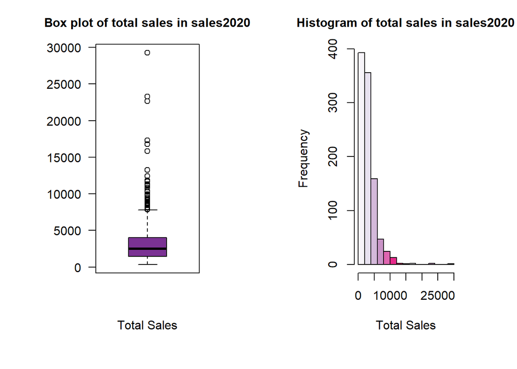

```r
#Present a box plot of total sales
par(mfcol=c(1,2),mai=c(1.6,1,0.4,2),mar=c(6.5, 6.5, 3, 4))
totsl_bar=boxplot(sales2020$Sales_Total,
        main="Box plot of total sales in sales2020",
        cex.main=1,
        xlab="Total Sales",
        col=brewer.pal(4,"PRGn"),
        las=1)
#Present a histogram of total sales
totsl_hist=hist(sales2020$Sales_Total,
        main="Histogram of total sales in sales2020",
        cex.main=1,
        xlab="Total Sales",
        ylab="Frequency",
        col=brewer.pal(8,"PuRd"),
        breaks=15)
```

The above boxplot and histogram depict that majority of the total sales(more than 75%) lies within 0 and 5000 and we can also observe that less sales lies between 10,000 and 30,000 approximately.

**2.2 Boxplot and histogram of numerical variable Quantity.**

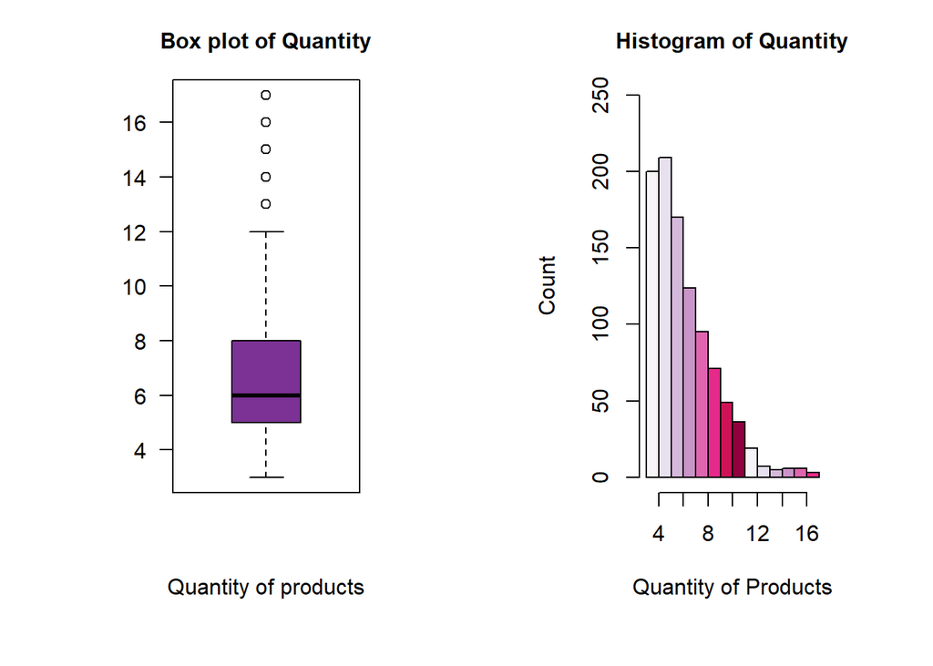

```r
#Present a box plot of), Quantity
par(mfrow=c(1,2),mai=c(1.6,1,0,2),mar=c(6.5, 6.5, 3, 4))
qty_bar=boxplot(sales2020$Quantity,
        main="Box plot of Quantity",
        cex.main=1,
        xlab="Quantity of products",
        col=brewer.pal(4,"PRGn"),
        las=1)
#Present a histogram of Quantity
qty_hist=hist(sales2020$Quantity,
        main="Histogram of Quantity",
        cex.main=1,
        xlab="Quantity of Products",
        ylab="Count",
        ylim=c(0,250),
        col=brewer.pal(8,"PuRd"),
        breaks=15)
```

The above boxplot and histogram depict that 75% of quantity lies within 3 to 8 approximately and there are outliers(data points that lie at an abnormal distance from other values in the distribution) present in the distribution.This distribution is skewed right since majority of data points lie above the median.

**2.3 Boxplot and histogram of numerical variable Discounts.**

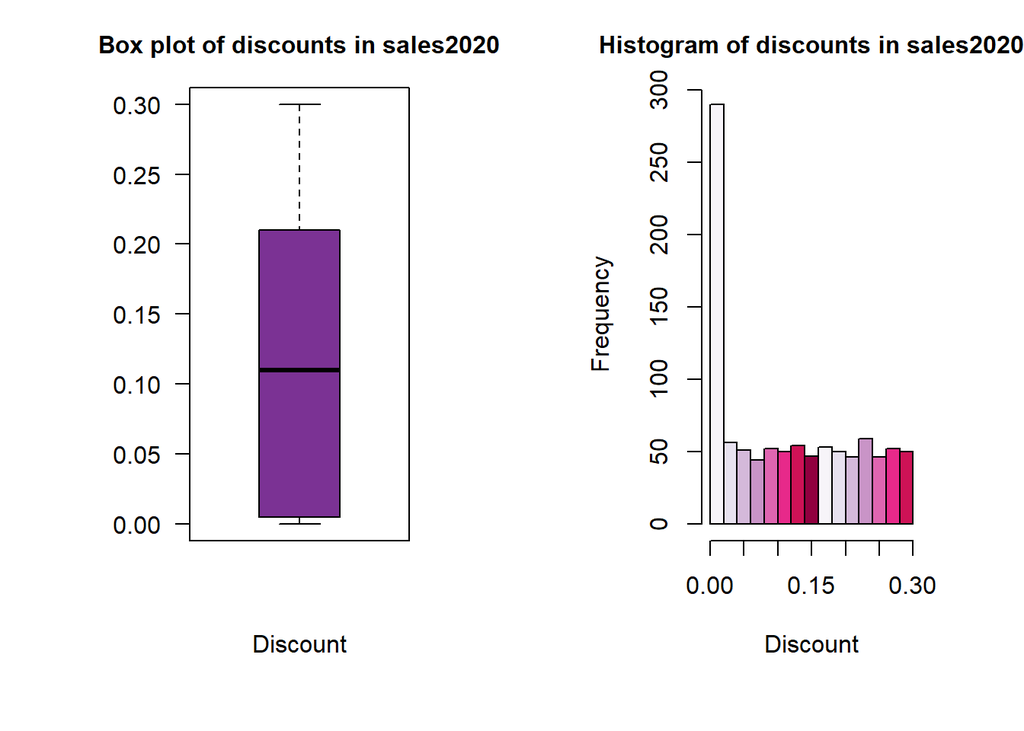

```r
#Present a box plot of all discounts
par(mfcol=c(1,2),mai=c(1.6,1,0.4,6),mar=c(6.5, 6.5, 3, 3.5))
disc_bar=boxplot(sales2020$Discount,
        main="Box plot of discounts in sales2020",
        cex.main=1,
        xlab="Discount",
        col=brewer.pal(4,"PRGn"),
        las=1)
#Present a histogram of all discounts
disc_hist=hist(sales2020$Discount,
        main="Histogram of discounts in sales2020",
        cex.main=1,
        xlab="Discount",
        ylab="Frequency",
        col=brewer.pal(8,"PuRd"),
        breaks=15)
```

**2.4 Box plot and histogram of numerical variable Profits.**

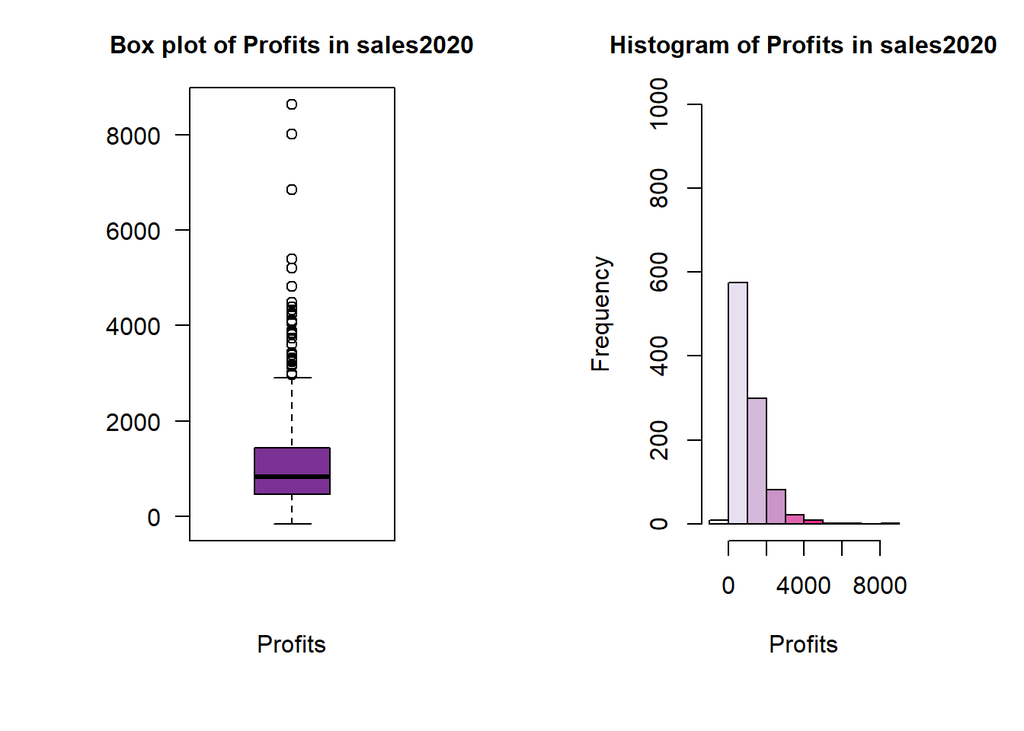

```r
#Present a box plot of all profits
par(mfcol=c(1,2),mai=c(1.6,1,0.4,1),mar=c(6.5, 6.5, 3, 4))
pft_bar=boxplot(sales2020$Profits,
        main="Box plot of Profits in sales2020",
        cex.main=1,
        xlab="Profits",
        col=brewer.pal(4,"PRGn"),
        las=1)
#Present a histogram of all profits
pft_hist=hist(sales2020$Profits,
        main="Histogram of Profits in sales2020",
        cex.main=1,
        xlab="Profits",
        ylab="Frequency",
        col=brewer.pal(8,"PuRd"),
        ylim=c(0,1000),
        breaks=10)
```

The above histogram and boxplot depicts that the majority of profit lie between 0 to 2000 approximately. Also, we can observe that there are negative values in the histogram indicating negative profits.We can focus on those products which attain negative profits for improving sales of the business.

**Task 3: Count and present categorical variable groups.**  
The categorical variables I chose to group are: Market, Segment, Department and Division. The observations of each category are grouped(count is calculated with the observations of each category) using a table and presented.

**3.1 Total Observations on categorical variable Market .**

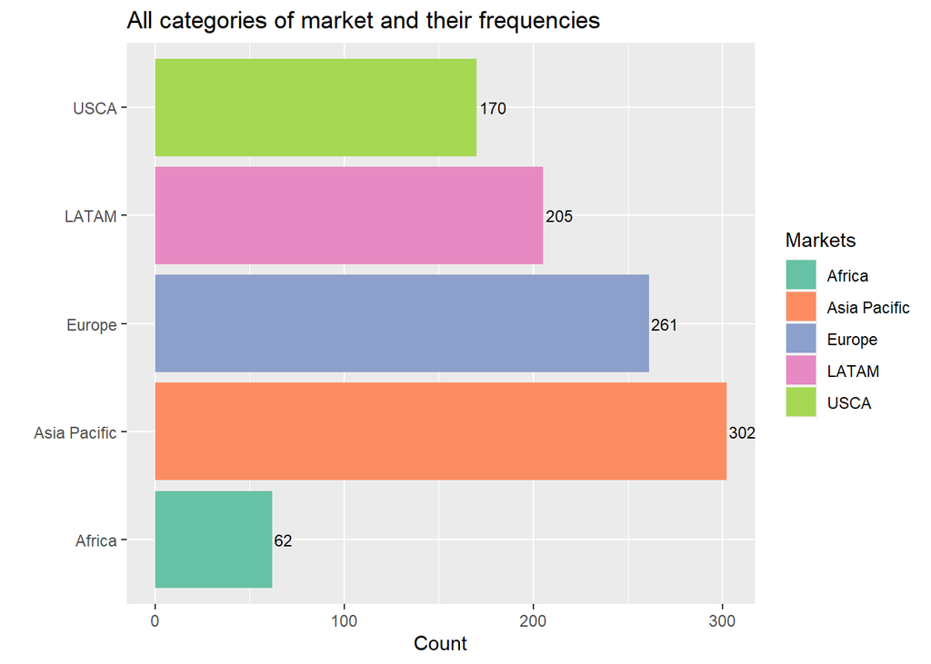

```r
#Get the count of observations using table command
mkt_tab <- table(sales2020$Market)
mkt_data<-data.frame(mkt_tab)
names(mkt_data)[1]<-"Markets"
#present bar graph
ggplot(mkt_data,aes(x=Freq,y=Markets,fill=Markets))+ggtitle("All categories of market and their frequencies")+labs(x="Count",y=" ")+ scale_fill_brewer(palette="Set2")+geom_bar(stat="identity")+geom_text(mapping=aes(label=Freq),position=position_dodge(width=0.9),cex=3,hjust=-0.1)
```

From the above bar graph, we can infer that Asia Pacific has more orders when compared to other markets whereas Africa has the least number of orders. We can also see that the count in USCA is similar to half of the count in Asia Pacific.

**3.2 Total Observations on categorical variable Division .**

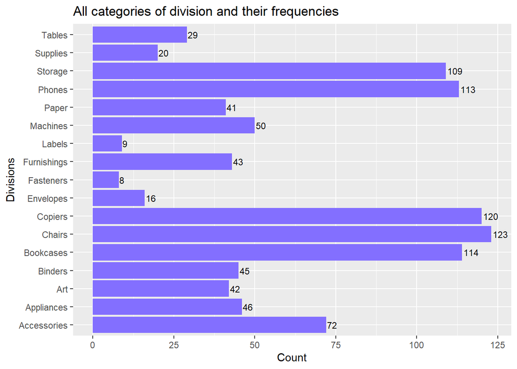

```r
#Get the count of observations using table command
dvs_tab <- table(sales2020$Division)
dvs_data<-data.frame(dvs_tab)
#present bar graph
ggplot(dvs_data,aes(x=Freq,y=Var1))+ggtitle("All categories of division and their frequencies")+labs(x="Count",y="Divisions")+geom_bar(stat="identity",fill="slateblue1")+geom_text(mapping=aes(label=Freq),position=position_dodge(width=0.9),cex=3,hjust=-0.1)
```

From the above bar graph, we can infer that Chairs were ordered approximately 123 times resulting in most ordered division during 2020. Following that, copiers were ordered 120 times and the least ordered division is Fasteners with 8 orders.

**3.3 Total Observations on categorical variable Segment .**

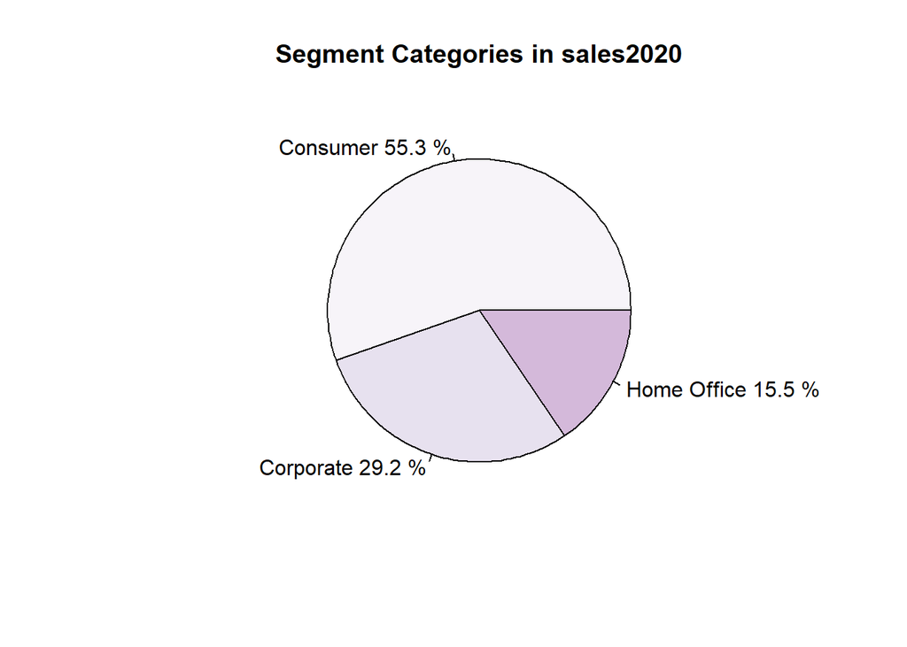

```r
#Get count using table command
seg_tab<-table(sales2020$Segment)
#Present pie chart
pie(seg_tab,main="Segment Categories in sales2020",
    col=brewer.pal(8,"PuRd"),
    labels=paste(names(seg_tab),
    sep=" ",round(100*seg_tab/sum(seg_tab),2),"%"))
```

When compared to other segments,orders placed under Consumer segment have majorly contributed(55.3% approx.) to the store company whereas orders of Home office contributed 15.5% only.

**3.4 Total Observations on categorical variable Department .**

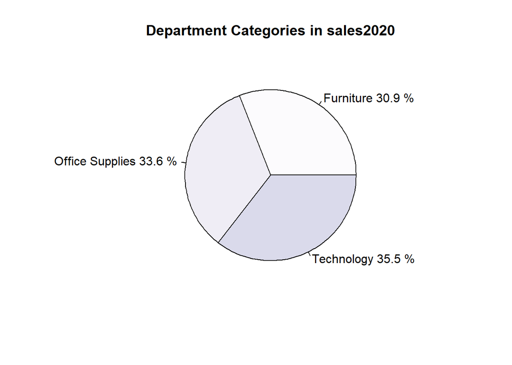

```r
#Get count using table command
dept_tab<-table(sales2020$Department)
#Present pie chart
pie(dept_tab,main="Department Categories in sales2020",
    col=brewer.pal(8,"Purples"),
    labels=paste(names(dept_tab),
    sep=" ",round(100*dept_tab/sum(dept_tab),2),"%"))
```

When compared to other segments,orders placed under Technology department has majorly contributed(35.5% approx.) to the store company whereas orders for Furniture contributed 30.9% only.

**Task 4: Business questions, statistics with sub-categories**  
In this task, I will be combining three categorical and numerical variables. A suitable question combining a categorical and a numerical variable will be asked for which statistical interpretation will be performed and presented via a graph.

**4.1 What is the total quantity per division?.**  
In this task, we need to calculate the total number of quantities sold per division using tapply() function. Then, a bar plot is presented with the obtained results.

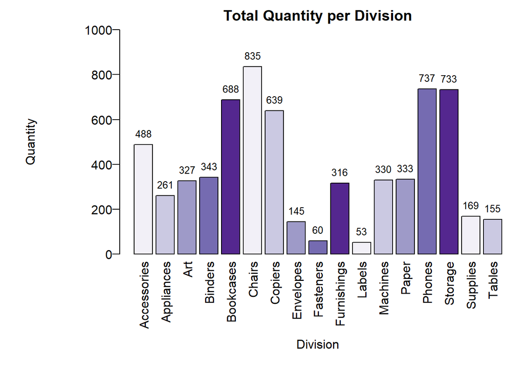

```r
#find the sum of quantities grouped by division using tapply() command
sum_qtydv <- tapply(sales2020$Quantity,sales2020$Division,sum)
par(mar = c(8,8, 2, 0.5), mgp = c(5.5, 0.5, 0))
#present bar plot
qtydv_bar=barplot(sum_qtydv,
              main="Total Quantity per Division",
              xlab="Division",
              ylab="Quantity",
              cex.name="1",
              cex.axis="1",
              ylim=c(0,1000),
              col=brewer.pal(5,"Purples"),
              las=2)
    text(y=sum_qtydv,
    qtydv_bar,
    round(sum_qtydv,2),
    cex=0.8,
    pos=3)
```

**Observations:** From the above bar plot, we can see that maximum number of products(count=835) ordered in 2020 is Chairs whereas the least number of products ordered was Labels. Phones and storage almost has the same quantity of products ordered.

**4.2 What is the average sales per market?.**  
In this task, we need to calculate the mean of sales grouped by each market using tapply() function. Then, a dot plot is presented with the obtained results.

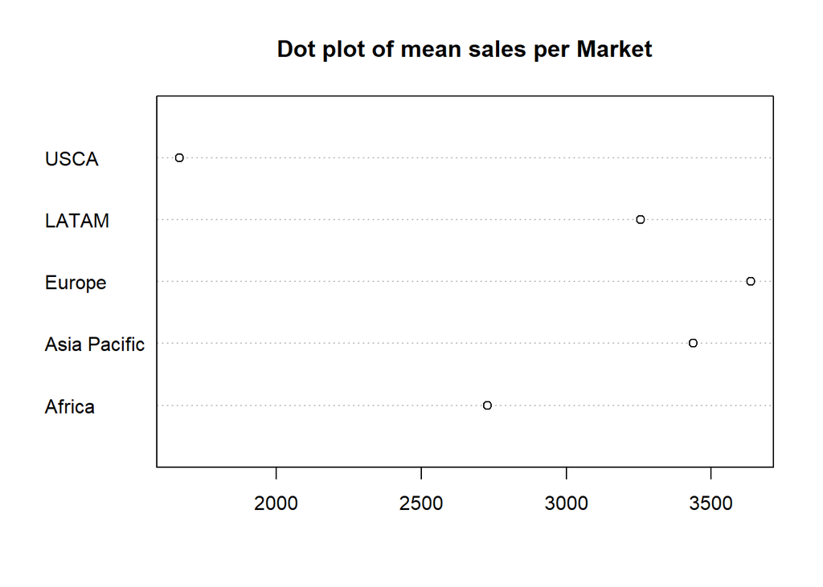

```r
#Calculate mean of sales grouped by each market using tapply() command.
mean_salemk <- tapply(sales2020$Sales_Total,sales2020$Market,mean)
#present dot chart.
dotchart(mean_salemk,main="Dot plot of mean sales per Market")
```

**Observations:** The above dot chart depicts that Europe has the highest average sales(more than 3500 USD approx.) when compared to other markets.We can also observe that USCA has the least average sales(1600 USD approx.).The average sales in LATAM and Asia Pacific are almost similar.

**4.3 What is the spread of shipping cost per segment?.**  
In this task, we need to calculate the standard deviation of shipping costs across each segment using tapply() command and present it using a pie chart.

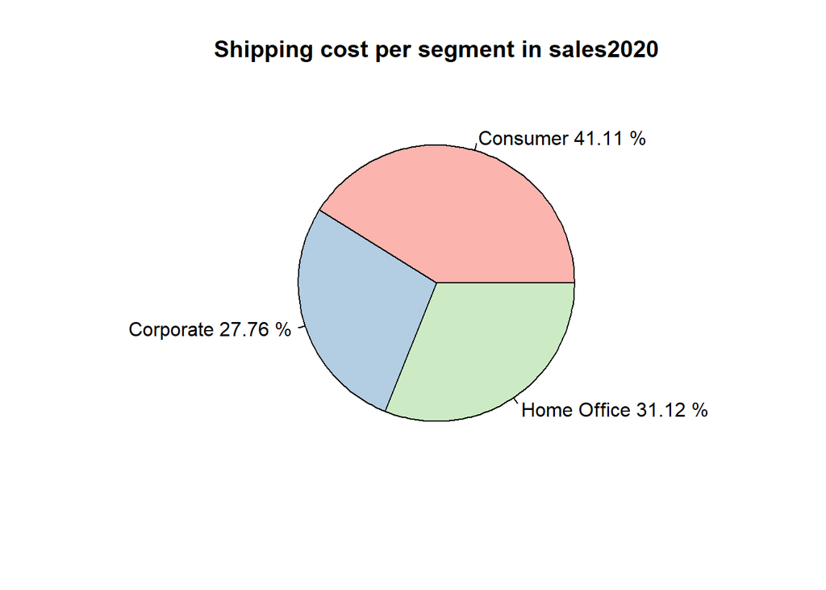

```r
#calculate standard deviation of shipping costs grouped by segment using tapply() command
sd_scseg <- tapply(sales2020$ShippingCost_Product,sales2020$Segment,sd)
#present pie chart
sc_pie=pie(sd_scseg,main="Shipping cost per segment in sales2020",
       col=brewer.pal(8,"Pastel1"),
       labels=paste(names(sd_scseg),
       sep=" ",round(100*sd_scseg/sum(sd_scseg),2),"%"))
```

**Observations:** The above pie chart depicts that the spread of shipping costs is highest for consumer segment contributing 41.11%.

**Task 5: Data Filtration**  
In this task, I will be choosing a category from Region i.e., Central America and I will be creating a new subset of data by filtering the data only for that category from sales2020. I chose question “What is the average Net Sale per Department?” for analyzing.Hence, I will be calculating and presenting the mean of net sales per department in Central America.

```r
#Filter data with region as Central America using dplyr::filter() function.
ca_data = dplyr::filter(sales2020, Region=="Central America")
#Calculate average net sales per department using tapply() command.
mean_netdpt <- tapply(ca_data$Net_Sale,ca_data$Department,mean)
knitr::kable(mean_netdpt,col.names = "Mean of Net Sales")
```

|  | Mean of Net Sales |
| --- | --- |
| Furniture | 2404.169 |
| Office Supplies | 2183.756 |
| Technology | 2044.428 |

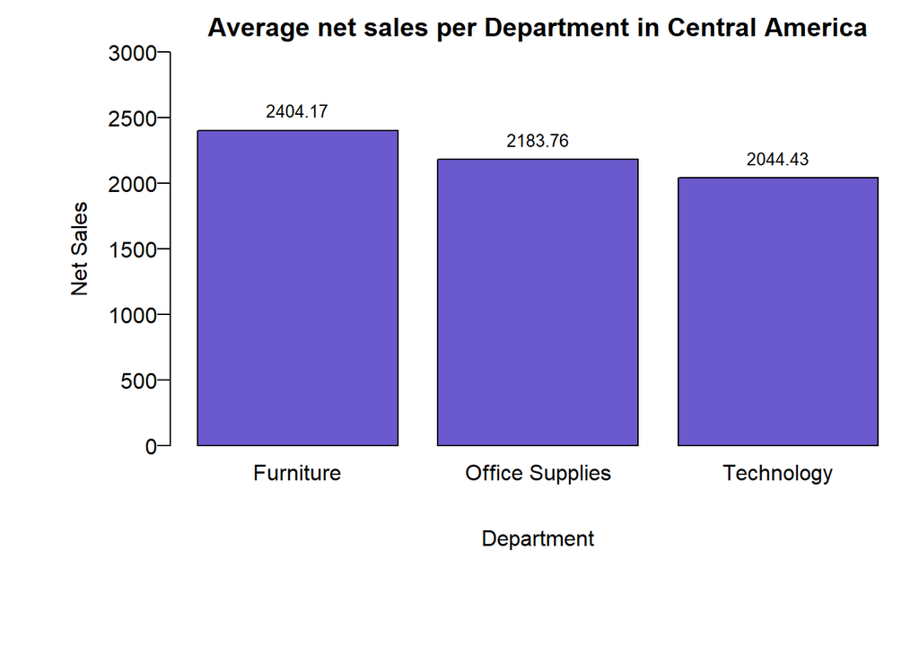

```r
#Present bar plot
par(mar = c(8, 6.5, 2, 0.5), mgp = c(3, 0.5, 0))
ca_bar=barplot(mean_netdpt,
              main="Average net sales per Department in Central America",
              xlab="Department",
              ylab="Net Sales",
              cex.name="1",
              cex.axis="1",
              ylim=c(0,3000),
              col="slateblue",
              las=1)
    text(y=mean_netdpt,
    ca_bar,
    round(mean_netdpt,2),
    cex=0.8,
    pos=3)
```

**Observations:** In Central America,the average net sales of Furniture is the highest(2400 USD approx.) whereas the mean of net sales with respect to technology(2050 USD approx.) is the least when compared to other departments.

**Task 6: Open Question - Compare the profits across each market.**  
The open question I chose is what is the impact of profits on every market or comparison of profits across markets. Market is a categorical variable and Profits is a numerical variable. The approach here is to compare the profits of each and every market using box plots.

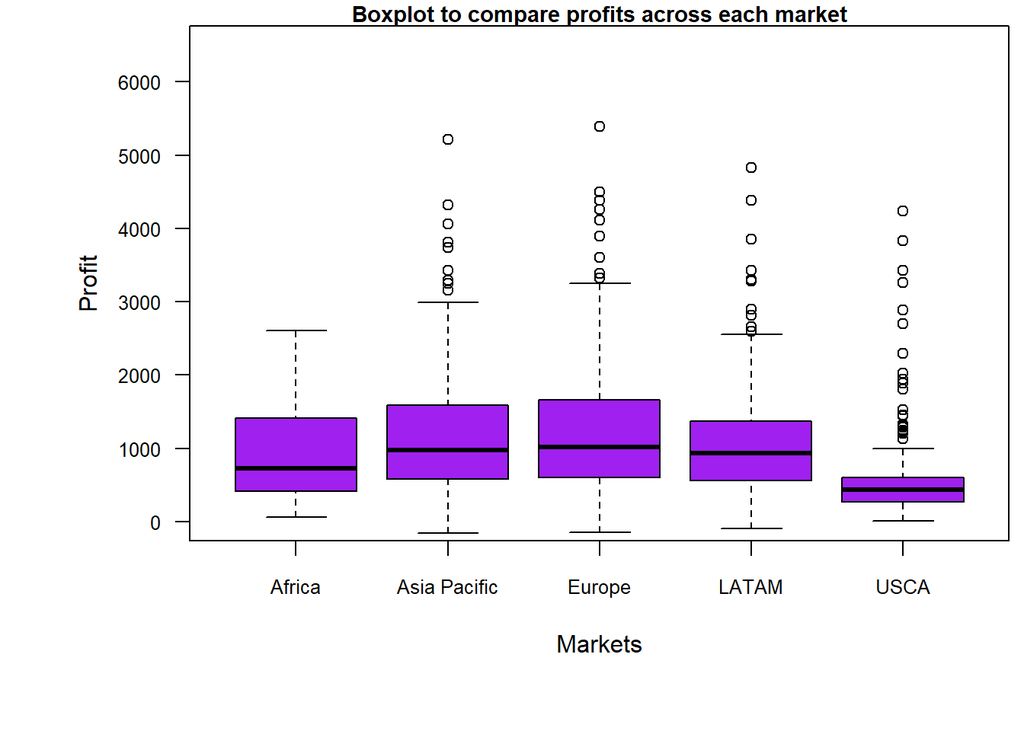

```r
#present box plots
par(mai=c(1.6,1.2,0.5,0.4),mar=c(6.5, 6.5, 0.9, 0.5),mgp=c(3, 1, 0))
pf_plot=boxplot(sales2020$Profits~sales2020$Market,data=ca_data,
        main= "Boxplot to compare profits across each market",
        xlab = "Markets",
        ylab="Profit",
        col= "purple",
        border="black",
        ylim=c(0,6500),
        cex.name=0.4,
        cex.axis=0.8,
        cex.main=0.9,
        las=1
        )
```

**Observations:** The following inferences can be made from the above box plots:

**Conclusion**

This project helped me gain a keen understanding on how to analyze, interpret and present data. Working with a real time data set, I gained exposure on how to handle data and form my own questions from it. Also, performing these descriptive statistical tasks enhanced my expertise level in R even more.  
Visualizations using ggplot(),boxplot(),barplot() and hist(),etc. are extremely useful to understand the relationship between each variable in the data set. Before every task, I asked questions like what are the outcomes of this task, how the data can be analyzed from the particular task and how it would enhance the business methods.Asking these questions made it easier for me.  
Thus, I was able to analyze patterns from the huge data set and I understood that it can be used to predict revenues, increase in sales, profit/loss, etc. that can enhance businesses in a positive direction.

**Bibliography**

Hooda, S. (2021, October 27). Top 10 Big Data Applications Across Industries. Simplilearn.Com. https://www.simplilearn.com/tutorials/big-data-tutorial/big-data-applications  
Barash, R. (2019, January 14).The Power of Retail Analytics. yodlee.com.  
https://www.yodlee.com/data-analytics/big-data-retail-analytics Chiluiza, D. (2021, October 1). RPubs - Introduction to data analysis using R: Histograms. Rpubs.Com.  
https://rpubs.com/Dee_Chiluiza/816756

**Appendix**

I am adding an additional file which contains the source R code for this report. I have attached the code file Rosary_Project6.Rmd.